[figure not shown]

# Parcours Data Analyst

## Projet 3 : Réalisez une étude de santé publique

### Thomas Dupouy - 03/2018

# Effectuez de très brèves recherches en vue d'identifier certaines causes de la faim.

Vous les présenterez en introduction de votre soutenance.

## Causes de la faim dans le monde

Source : [Wikipédia](https://fr.wikipedia.org/wiki/Faim#Causes_de_la_faim_dans_le_monde)

Les causes de la faim dans le monde sont multiples et interdépendantes. De façon pragmatique, elles peuvent être regroupées en deux types d’inaccessibilité à l’alimentation : **l’inaccessibilité économique**, quand la nourriture est disponible mais trop chère pour que la population puisse l’acheter et **l’inaccessibilité physique** ou géographique, quand la nourriture n’est simplement pas disponible. Ces deux types d’inaccessibilités trouvent leurs causes dans différents facteurs.

### Inaccessibilité économique

Dans un système de libre marché, les prix sont définis par l’offre et la demande. Quand les prix des denrées alimentaires flambent, les populations des pays les plus pauvres, qui dépensent près de 70 % de leur budget dans l'alimentation, perdent l'accès à la nourriture.

#### Demande alimentaire

La croissance démographique et la croissance des niveaux de vie dans les pays en développement font inéluctablement pression sur la demande alimentaire.

#### Offre alimentaire

L’évolution du prix du pétrole influence l’offre alimentaire.

### Inaccessibilité physique

L’inaccessibilité physique (ou géographique) est due en partie au phénomène d’urbanisation vécu par les pays du Sud depuis quelques décennies.

#### La guerre et les problèmes climatiques

La guerre et les guerres civiles ainsi que les problèmes climatiques (sècheresses, inondations…) ont une influence sur la sous-alimentation à de nombreux niveaux. Les conflits entraînent souvent la déportation des populations. Ils empêchent donc la culture des champs mais aussi l’utilisation des récoltes. S’ils ne détruisent pas les infrastructures, ils empêchent, en rendant dangereuse, leur utilisation. Il en va de même pour les problèmes climatiques.

# Téléchargez les données

Selon l'énoncé du problème et ma compréhension, les données suivantes seront à récupérer du site du FAO :

| population | equilibre_prod | dispo_alim | sous_nutrition |
| --- | --- | --- | --- |
| Pour les années 2010 à dernière disponible | disponibilité intérieure | la nature du produit (deux valeurs possibles “animal” ou “végétal”) | pays |
| pays | aliments pour animaux | disponibilité alimentaire en tonnes | code_pays |
| code_pays | semences | disponibilité alimentaire en Kcal/personne/jour | année |
| annee | pertes | disponibilité de protéines en g/personne/jour | nb_personnes |
| population | transformés | disponibilité de matières grasses en g/personne/jour |  |
|  | nourriture |  |  |
|  | autres utilisations |  |  |

Également une table **FBS_cereales** indiquant les produits identifiés comme céréales par la FAO

```r
setwd("/data/FAOSTAT/")
library(dplyr) # très utile
library(reshape2) # pour les translations dcast
```

### Population

[figure not shown]

```r
Population_1 <- read.csv("Population_1.csv",header=T)
key <- sprintf('%d%d',Population_1$Code.zone,Population_1$Code.année)
cat(nrow(Population_1),all(duplicated(key))); head(Population_1);
```

```
8780 FALSE
```

| Code.Domaine | Domaine | Code.zone | Zone | Code.Élément | Élément | Code.Produit | Produit | Code.année | Année | Unité | Valeur | Symbole | Description.du.Symbole |
| --- | --- | --- | --- | --- | --- | --- | --- | --- | --- | --- | --- | --- | --- |
| OA | Séries temporelles annuelles | 2 | Afghanistan | 511 | Population totale | 3010 | Population-Estimations | 2010 | 2010 | 1000 personnes | 28803.2 | XU | UNDESA, Population Division – World Population Prospects, the 2015 Revision |
| OA | Séries temporelles annuelles | 2 | Afghanistan | 511 | Population totale | 3010 | Population-Estimations | 2011 | 2011 | 1000 personnes | 29708.6 | XU | UNDESA, Population Division – World Population Prospects, the 2015 Revision |
| OA | Séries temporelles annuelles | 2 | Afghanistan | 511 | Population totale | 3010 | Population-Estimations | 2012 | 2012 | 1000 personnes | 30697.0 | XU | UNDESA, Population Division – World Population Prospects, the 2015 Revision |
| OA | Séries temporelles annuelles | 2 | Afghanistan | 511 | Population totale | 3010 | Population-Estimations | 2013 | 2013 | 1000 personnes | 31731.7 | XU | UNDESA, Population Division – World Population Prospects, the 2015 Revision |
| OA | Séries temporelles annuelles | 2 | Afghanistan | 511 | Population totale | 3010 | Population-Estimations | 2014 | 2014 | 1000 personnes | 32758.0 | XU | UNDESA, Population Division – World Population Prospects, the 2015 Revision |
| OA | Séries temporelles annuelles | 2 | Afghanistan | 511 | Population totale | 3010 | Population-Estimations | 2015 | 2015 | 1000 personnes | 33736.5 | XU | UNDESA, Population Division – World Population Prospects, the 2015 Revision |

```r
# Sans sélectionner les doublons sur la Chine
Population_2 <- read.csv("Population_2.csv",header=T); dim(Population_2); head(Population_2)
```

1. 8580

2. 14

| Code.Domaine | Domaine | Code.zone | Zone | Code.Élément | Élément | Code.Produit | Produit | Code.année | Année | Unité | Valeur | Symbole | Description.du.Symbole |
| --- | --- | --- | --- | --- | --- | --- | --- | --- | --- | --- | --- | --- | --- |
| OA | Séries temporelles annuelles | 2 | Afghanistan | 511 | Population totale | 3010 | Population-Estimations | 2010 | 2010 | 1000 personnes | 28803.2 | XU | UNDESA, Population Division – World Population Prospects, the 2015 Revision |
| OA | Séries temporelles annuelles | 2 | Afghanistan | 511 | Population totale | 3010 | Population-Estimations | 2011 | 2011 | 1000 personnes | 29708.6 | XU | UNDESA, Population Division – World Population Prospects, the 2015 Revision |
| OA | Séries temporelles annuelles | 2 | Afghanistan | 511 | Population totale | 3010 | Population-Estimations | 2012 | 2012 | 1000 personnes | 30697.0 | XU | UNDESA, Population Division – World Population Prospects, the 2015 Revision |
| OA | Séries temporelles annuelles | 2 | Afghanistan | 511 | Population totale | 3010 | Population-Estimations | 2013 | 2013 | 1000 personnes | 31731.7 | XU | UNDESA, Population Division – World Population Prospects, the 2015 Revision |
| OA | Séries temporelles annuelles | 2 | Afghanistan | 511 | Population totale | 3010 | Population-Estimations | 2014 | 2014 | 1000 personnes | 32758.0 | XU | UNDESA, Population Division – World Population Prospects, the 2015 Revision |
| OA | Séries temporelles annuelles | 2 | Afghanistan | 511 | Population totale | 3010 | Population-Estimations | 2015 | 2015 | 1000 personnes | 33736.5 | XU | UNDESA, Population Division – World Population Prospects, the 2015 Revision |

Une information de Population est également disponible au téléchargement dans les tables FBS, cependant elle semble moins précise et limitée à 2013. J'ai donc priviliégié l'information disponible dans la table Séries Temporelles.

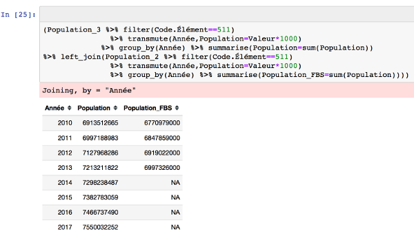

### FBS Animal

[figure not shown]

```r
FBS_animal <- read.csv("FBS_animal.csv",header=T)
key <- sprintf('%d%d%d',FBS_animal$Code.Pays,FBS_animal$Année,FBS_animal$Code.Produit)
cat(nrow(FBS_animal),all(duplicated(key))); head(FBS_animal)
```

```
145272 FALSE
```

| Code.Domaine | Domaine | Code.Pays | Pays | Code.Élément | Élément | Code.Produit | Produit | Code.Année | Année | Unité | Valeur | Symbole | Description.du.Symbole |
| --- | --- | --- | --- | --- | --- | --- | --- | --- | --- | --- | --- | --- | --- |
| FBS | Bilans Alimentaires | 2 | Afghanistan | 5511 | Production | 2731 | Viande de Bovins | 2012 | 2012 | Milliers de tonnes | 139 | S | Données standardisées |
| FBS | Bilans Alimentaires | 2 | Afghanistan | 5511 | Production | 2731 | Viande de Bovins | 2013 | 2013 | Milliers de tonnes | 134 | S | Données standardisées |
| FBS | Bilans Alimentaires | 2 | Afghanistan | 5611 | Importations - Quantité | 2731 | Viande de Bovins | 2012 | 2012 | Milliers de tonnes | 14 | S | Données standardisées |
| FBS | Bilans Alimentaires | 2 | Afghanistan | 5611 | Importations - Quantité | 2731 | Viande de Bovins | 2013 | 2013 | Milliers de tonnes | 6 | S | Données standardisées |
| FBS | Bilans Alimentaires | 2 | Afghanistan | 5301 | Disponibilité intérieure | 2731 | Viande de Bovins | 2012 | 2012 | Milliers de tonnes | 153 | S | Données standardisées |
| FBS | Bilans Alimentaires | 2 | Afghanistan | 5301 | Disponibilité intérieure | 2731 | Viande de Bovins | 2013 | 2013 | Milliers de tonnes | 140 | S | Données standardisées |

### FBS Végétal

[figure not shown]

```r
FBS_vegetal <- read.csv("FBS_vegetal.csv",header=T)
key <- sprintf('%d%d%d',FBS_vegetal$Code.Pays,FBS_vegetal$Année,FBS_vegetal$Code.Produit)
cat(nrow(FBS_vegetal),all(duplicated(key))); head(FBS_vegetal)
```

```
409337 FALSE
```

| Code.Domaine | Domaine | Code.Pays | Pays | Code.Élément | Élément | Code.Produit | Produit | Code.Année | Année | Unité | Valeur | Symbole | Description.du.Symbole |
| --- | --- | --- | --- | --- | --- | --- | --- | --- | --- | --- | --- | --- | --- |
| FBS | Bilans Alimentaires | 2 | Afghanistan | 5511 | Production | 2511 | Blé | 2012 | 2012 | Milliers de tonnes | 5050 | S | Données standardisées |
| FBS | Bilans Alimentaires | 2 | Afghanistan | 5511 | Production | 2511 | Blé | 2013 | 2013 | Milliers de tonnes | 5169 | S | Données standardisées |
| FBS | Bilans Alimentaires | 2 | Afghanistan | 5611 | Importations - Quantité | 2511 | Blé | 2012 | 2012 | Milliers de tonnes | 1334 | S | Données standardisées |
| FBS | Bilans Alimentaires | 2 | Afghanistan | 5611 | Importations - Quantité | 2511 | Blé | 2013 | 2013 | Milliers de tonnes | 1173 | S | Données standardisées |
| FBS | Bilans Alimentaires | 2 | Afghanistan | 5072 | Variation de stock | 2511 | Blé | 2012 | 2012 | Milliers de tonnes | -500 | S | Données standardisées |
| FBS | Bilans Alimentaires | 2 | Afghanistan | 5072 | Variation de stock | 2511 | Blé | 2013 | 2013 | Milliers de tonnes | -350 | S | Données standardisées |

### FBS Céréales

[figure not shown]

```r
FBS_cereales <- read.csv("FBS_cereales.csv",header=T)
key <- sprintf('%d%d%d',FBS_cereales$Code.Pays,FBS_cereales$Année,FBS_cereales$Code.Produit)
cat(nrow(FBS_cereales),all(duplicated(key))); head(FBS_cereales)
```

```
16057 FALSE
```

| Code.Domaine | Domaine | Code.Pays | Pays | Code.Élément | Élément | Code.Produit | Produit | Code.Année | Année | Unité | Valeur | Symbole | Description.du.Symbole |
| --- | --- | --- | --- | --- | --- | --- | --- | --- | --- | --- | --- | --- | --- |
| FBS | Bilans Alimentaires | 2 | Afghanistan | 5511 | Production | 2511 | Blé | 2013 | 2013 | Milliers de tonnes | 5169 | S | Données standardisées |
| FBS | Bilans Alimentaires | 2 | Afghanistan | 5611 | Importations - Quantité | 2511 | Blé | 2013 | 2013 | Milliers de tonnes | 1173 | S | Données standardisées |
| FBS | Bilans Alimentaires | 2 | Afghanistan | 5072 | Variation de stock | 2511 | Blé | 2013 | 2013 | Milliers de tonnes | -350 | S | Données standardisées |
| FBS | Bilans Alimentaires | 2 | Afghanistan | 5301 | Disponibilité intérieure | 2511 | Blé | 2013 | 2013 | Milliers de tonnes | 5992 | S | Données standardisées |
| FBS | Bilans Alimentaires | 2 | Afghanistan | 5527 | Semences | 2511 | Blé | 2013 | 2013 | Milliers de tonnes | 322 | S | Données standardisées |
| FBS | Bilans Alimentaires | 2 | Afghanistan | 5123 | Pertes | 2511 | Blé | 2013 | 2013 | Milliers de tonnes | 775 | S | Données standardisées |

### Sous-alimentation

[figure not shown]

```r
SousAlim <-(read.csv("sous-alimentation.csv",header=T)
            %>% mutate(Année=as.integer(sub("(\\d{4})-.+","\\1", Année))+1))
key <- sprintf('%d%d',SousAlim$Code.zone,SousAlim$Année)
cat(nrow(SousAlim),all(duplicated(key))); head(SousAlim)
```

```
1200 FALSE
```

| Code.Domaine | Domaine | Code.zone | Zone | Code.Élément | Élément | Code.Produit | Produit | Code.année | Année | Unité | Valeur | Symbole | Description.du.Symbole |
| --- | --- | --- | --- | --- | --- | --- | --- | --- | --- | --- | --- | --- | --- |
| FS | Données de la sécurité alimentaire | 2 | Afghanistan | 6132 | Valeur | 21001 | Nombre de personnes sous-alimentées (millions) (moyenne sur 3 ans) | 20102012 | 2011 | millions | 6.4 | F | Estimation FAO |
| FS | Données de la sécurité alimentaire | 2 | Afghanistan | 6132 | Valeur | 21001 | Nombre de personnes sous-alimentées (millions) (moyenne sur 3 ans) | 20112013 | 2012 | millions | 6.8 | F | Estimation FAO |
| FS | Données de la sécurité alimentaire | 2 | Afghanistan | 6132 | Valeur | 21001 | Nombre de personnes sous-alimentées (millions) (moyenne sur 3 ans) | 20122014 | 2013 | millions | 7.2 | F | Estimation FAO |
| FS | Données de la sécurité alimentaire | 2 | Afghanistan | 6132 | Valeur | 21001 | Nombre de personnes sous-alimentées (millions) (moyenne sur 3 ans) | 20132015 | 2014 | millions | 7.5 | F | Estimation FAO |
| FS | Données de la sécurité alimentaire | 2 | Afghanistan | 6132 | Valeur | 21001 | Nombre de personnes sous-alimentées (millions) (moyenne sur 3 ans) | 20142016 | 2015 | millions | 7.5 | F | Estimation FAO |
| FS | Données de la sécurité alimentaire | 2 | Afghanistan | 6132 | Valeur | 21001 | Nombre de personnes sous-alimentées (millions) (moyenne sur 3 ans) | 20152017 | 2016 | millions | NA | NA | Non applicable |

```r
# Définition de variables
AnnéeÉtudiée <- 2013
# Concaténation des deux dataframes FBS
FBS <- rbind(FBS_animal,FBS_vegetal)
# échantillon de pays
liste_pays <- c("France","Chine","Inde","États-Unis d'Amérique","Pérou")
# échantillons de produits alimentaires
liste_produits <- c("Riz (Eq Blanchi)","Blé","Oeufs","Pommes de Terre","Viande de Bovins")
# Liste des produits dans FBS_vegetal
ListeProduitsVégétaux <- FBS_vegetal %>% select(Code.Produit) %>% distinct()
# Liste des produits dans FBS_vegetal
ListeProduitsAnimal <- FBS_animal %>% select(Code.Produit) %>% distinct()
# Population en 2013
Population2k13 <- Population_2 %>% filter(Année==AnnéeÉtudiée&Code.Élément==511) %>% summarise(sum(Valeur))*1000
# Valeur moyenne du besoin quotidien en Kcal
NécessitéKcalJourPersonne <- round(mean(c(2335,2786,1846,2223,2682,3199,1941,2337,3164,3775,2154,2594)))
```

```r
# Liste des codes Éléments disponibles
rbind(FBS %>% select(Code.Élément,Élément) %>% distinct(),
Population_1 %>% select(Code.Élément,Élément) %>% distinct())
```

| Code.Élément | Élément |
| --- | --- |
| 5511 | Production |
| 5611 | Importations - Quantité |
| 5301 | Disponibilité intérieure |
| 5142 | Nourriture |
| 645 | Disponibilité alimentaire en quantité (kg/personne/an) |
| 664 | Disponibilité alimentaire (Kcal/personne/jour) |
| 674 | Disponibilité de protéines en quantité (g/personne/jour) |
| 684 | Disponibilité de matière grasse en quantité (g/personne/jour) |
| 5527 | Semences |
| 5123 | Pertes |
| 5911 | Exportations - Quantité |
| 5521 | Aliments pour animaux |
| 5154 | Autres Utilisations |
| 5072 | Variation de stock |
| 5131 | Traitement |
| 511 | Population totale |
| 512 | Hommes |
| 513 | Femmes |
| 551 | Population rurale |
| 561 | Population urbaine |

```r
# Liste des produits dans FBS
FBS %>% select(Code.Produit,Produit) %>% distinct() %>% arrange(Code.Produit)
```

| Code.Produit | Produit |
| --- | --- |
| 2511 | Blé |
| 2513 | Orge |
| 2514 | Maïs |
| 2515 | Seigle |
| 2516 | Avoine |
| 2517 | Millet |
| 2518 | Sorgho |
| 2520 | Céréales, Autres |
| 2531 | Pommes de Terre |
| 2532 | Manioc |
| 2533 | Patates douces |
| 2534 | Racines, Nda |
| 2535 | Ignames |
| 2536 | Sucre, canne |
| 2537 | Sucre, betterave |
| 2541 | Sucre non centrifugé |
| 2542 | Sucre Eq Brut |
| 2543 | Edulcorants Autres |
| 2546 | Haricots |
| 2547 | Pois |
| 2549 | Légumineuses Autres |
| 2551 | Noix |
| 2555 | Soja |
| 2556 | Arachides Decortiquees |
| 2557 | Graines de tournesol |
| 2558 | Graines Colza/Moutarde |
| 2559 | Graines de coton |
| 2560 | Coco (Incl Coprah) |
| 2561 | Sésame |
| 2562 | Palmistes |
| ⋮ | ⋮ |
| 2657 | Boissons Fermentés |
| 2658 | Boissons Alcooliques |
| 2659 | Alcool, non Comestible |
| 2680 | Aliments pour enfants |
| 2731 | Viande de Bovins |
| 2732 | Viande d'Ovins/Caprins |
| 2733 | Viande de Suides |
| 2734 | Viande de Volailles |
| 2735 | Viande, Autre |
| 2736 | Abats Comestible |
| 2737 | Graisses Animales Crue |
| 2740 | Beurre, Ghee |
| 2743 | Crème |
| 2744 | Oeufs |
| 2745 | Miel |
| 2761 | Poissons Eau Douce |
| 2762 | Perciform |
| 2763 | Poissons Pelagiques |
| 2764 | Poissons Marins, Autres |
| 2765 | Crustacés |
| 2766 | Cephalopodes |
| 2767 | Mollusques, Autres |
| 2768 | Viande de Anim Aquatiq |
| 2769 | Animaux Aquatiques Autre |
| 2775 | Plantes Aquatiques |
| 2781 | Huiles de Poissons |
| 2782 | Huiles de Foie de Poisso |
| 2805 | Riz (Eq Blanchi) |
| 2848 | Lait - Excl Beurre |
| 2899 | Miscellanees |

# Population

**Identifiez les grandes tendances**

Créez un dataframe contenant les informations de population de chaque pays.

Calculez le nombre total d’humains sur la planète. Critiquez votre résultat. En cas d’anomalie, analysez et effectuer les corrections nécessaires.

A faire : donnez le résultat de votre calcul pour l'année 2013, ainsi que pour la dernière année disponible au jour où vous effectuez ce projet.

```r
(Population_1
 %>% filter(Code.Élément==511) %>% group_by(Année)
 %>% summarise(Population=sum(Valeur)*1000)
 %>% filter(Année%in%c(2013,2017))) # x 1000 habitants
```

| Année | Population |
| --- | --- |
| 2013 | 15840496133 |
| 2017 | 16541426199 |

**Ce résultat me semble élevé !!! Correction à effectuer : diminuer le nombre d'habitants sur Terre ?** 😱😱😱

```r
(Population_1
 %>% filter(Code.Élément==511&Année==AnnéeÉtudiée)
 %>% select(Zone,Valeur)
 %>% distinct()
 %>% filter(grepl("Chine", Zone)))
```

| Zone | Valeur |
| --- | --- |
| Chine - RAS de Hong-Kong | 7148.570 |
| Chine - RAS de Macao | 575.841 |
| Chine, continentale | 1382790.000 |
| Chine, Taiwan Province de | 23339.900 |
| Chine | 1413860.000 |

😛😛😛

```r
# Le fichier Population_2 ne contient pas les doublons sur la Chine
Population <- (Population_2
               %>% filter(Code.Élément==511)
               %>% transmute(Code.Pays=Code.zone,Pays=Zone,Année,Population=Valeur*1000))
Population %>% filter(Année%in%c(2013,2017)) %>% group_by(Année) %>% summarise(Population=sum(Population))
```

| Année | Population |
| --- | --- |
| 2013 | 7213211822 |
| 2017 | 7550032252 |

# Bilans Alimentaires

## Parmi les documents sur les Bilans alimentaires que vous avez téléchargés, il y a des informations redondantes.

**A faire : Identifiez ces redondances, en donnant par exemple votre réponse sous forme de formule mathématique**

En effet, certaines peuvent se calculer à partir d'autres :

| Production (Production) | Disponibilité intérieure | Importations (Import Quantity) |
| --- | --- | --- |
| Semences (Seed) | Exportations (Export Quantity) | Pertes (Waste) |
| Variation de stock (Stock Variation) | Nourriture (Food) | Aliments pour animaux (Feed) |
| Traitement (Processed) | Autres utilisations (Other uses) |  |

**Extrait du Glossaire FBS**

| Code Élément | Élément | Description |
| --- | --- | --- |
| 664 | Disponibilité alimentaire | Données calculées (Kcal/personne/jour) |
| 645 | Disponibilité alimentaire en quantité | Données calculées (kg/personne/an) **Nourriture*1000/Population totale** |
| 5301 | Disponibilité intérieure | **Production + importations - exportations + évolution des stocks (augmentation ou diminution) = disponibilités servant à une utilisation intérieure**.Il existe plusieurs définitions des disponibilité… |
| 5511 | Production | Les chiffres concernent la production intérieure totale, réalisée à l'intérieur ou hors du secteur agricole, c'est-à-dire qu'elle comprend aussi la production non commerciale et la production des jard… |
| 5611 | Importations - Quantité | Données standardisées |
| 5911 | Exportations - Quantité | Données standardisées |
| 5521 | Aliments pour animaux | Les données se rapportent à la quantité du produit concerné disponible pour alimenter le bétail et la volaille au cours de la période de référence, qu'il s'agisse d'une production nationale ou de prod… |
| 5527 | Semences | Les données comprennent les quantités du produit concerné mises de côté au cours de la période de référence pour les semis ou pour la plantation (et plus généralement pour la reproduction, par exemple… |
| 5123 | Pertes | Les quantités du produit considéré qui sont perdues en déchets de toutes sortes pendant l'année et à toutes les étapes entre la production et les ménages, soit, lors de l'entreposage et du transport. … |
| 5142 | Nourriture | Les données se rapportent au montant total du produit disponible pour la consommation humaine au cours de la période de référence. Source: FAO. 1986. The ICS users' manual. Interlinked computer strora… |
| 5154 | Autres Utilisations | Les statistiques se rapportent à la quantité de produits utilisée à des fins non alimentaires, par exemple, l'huile servant à fabriquer du savon. Source: FAO. 1986. The ICS users' manual. Interlinked … |
| 5072 | Variation de stock | Il s'agit des variations des stocks qui se produisent durant la période de référence à tous les niveaux depuis la production jusqu'au commerce de détail, c'est-à-dire que sont comprises les fluctuatio… |
| 5131 | Traitement | Données standardisées |

**Calculez (pour chaque pays et chaque produit) la disponibilité alimentaire en kcal. Vous le ferez à partir de ces informations :**

Population de chaque pays ;

Disponibilité alimentaire ("Food Supply" en anglais) donnée pour chaque produit et pour chaque pays en kcal/personne/jour ,

A partir de cette dernière information, et à partir du poids de la disponibilité alimentaire (pour chaque pays et chaque produit), calculez pour chaque produit le ratio "énergie/poids", que vous donnerez en kcal/kg.

DispoKcal : Disponibilité alimentaire en Kcal/personne/jour x Population Pays x 365 = Disponibilité alimentaire en Kcal

DispoKg : Disponibilité alimentaire en kg/personne/an x Population Pays = Disponibilité alimentaire en Kg

```r
Dispo2k13 <- (FBS
    %>% filter(Code.Élément%in%c(664,645)&Année==AnnéeÉtudiée)
    %>% dcast(Code.Pays+Code.Produit+Produit+Année~Code.Élément,value.var="Valeur")
    %>% rename("Kcal"="664","Kg"="645")
    %>% left_join(Population,by=c("Code.Pays","Année"))
    %>% mutate(DispoKcal=Kcal*Population*365,DispoKg=Kg*Population)
    %>% filter(DispoKg>0) # nettoyage
    %>% mutate(Ratio=DispoKcal/DispoKg)
    %>% select(-Kcal,-Kg)
); Dispo2k13 %>% filter(Pays%in%liste_pays&Produit%in%liste_produits)
```

| Code.Pays | Code.Produit | Produit | Année | Pays | Population | DispoKcal | DispoKg | Ratio |
| --- | --- | --- | --- | --- | --- | --- | --- | --- |
| 68 | 2511 | Blé | 2013 | France | 63919900 | 1.892125e+13 | 6930834757 | 2730.0101 |
| 68 | 2531 | Pommes de Terre | 2013 | France | 63919900 | 2.216423e+12 | 3438251421 | 644.6365 |
| 68 | 2731 | Viande de Bovins | 2013 | France | 63919900 | 1.773138e+12 | 1521932819 | 1165.0567 |
| 68 | 2744 | Oeufs | 2013 | France | 63919900 | 1.189869e+12 | 839268287 | 1417.7456 |
| 68 | 2805 | Riz (Eq Blanchi) | 2013 | France | 63919900 | 1.213200e+12 | 311929112 | 3889.3443 |
| 100 | 2511 | Blé | 2013 | Inde | 1278560000 | 2.412707e+14 | 77429593600 | 3116.0007 |
| 100 | 2531 | Pommes de Terre | 2013 | Inde | 1278560000 | 2.100035e+13 | 31196864000 | 673.1557 |
| 100 | 2731 | Viande de Bovins | 2013 | Inde | 1278560000 | 1.400023e+12 | 1035633600 | 1351.8519 |
| 100 | 2744 | Oeufs | 2013 | Inde | 1278560000 | 4.666744e+12 | 3298684800 | 1414.7287 |
| 100 | 2805 | Riz (Eq Blanchi) | 2013 | Inde | 1278560000 | 3.215387e+14 | 88847134400 | 3619.0099 |
| 170 | 2511 | Blé | 2013 | Pérou | 30565700 | 3.960551e+12 | 1715347084 | 2308.8917 |
| 170 | 2531 | Pommes de Terre | 2013 | Pérou | 30565700 | 2.476739e+12 | 2521670250 | 982.1818 |
| 170 | 2731 | Viande de Bovins | 2013 | Pérou | 30565700 | 1.673472e+11 | 143353133 | 1167.3774 |
| 170 | 2744 | Oeufs | 2013 | Pérou | 30565700 | 3.458509e+11 | 267755532 | 1291.6667 |
| 170 | 2805 | Riz (Eq Blanchi) | 2013 | Pérou | 30565700 | 5.790213e+12 | 1495274044 | 3872.3426 |
| 231 | 2511 | Blé | 2013 | États-Unis d'Amérique | 315537000 | 6.898743e+13 | 25378640910 | 2718.3265 |
| 231 | 2531 | Pommes de Terre | 2013 | États-Unis d'Amérique | 315537000 | 9.674364e+12 | 16370059560 | 590.9792 |
| 231 | 2731 | Viande de Bovins | 2013 | États-Unis d'Amérique | 315537000 | 1.151710e+13 | 11435060880 | 1007.1744 |
| 231 | 2744 | Oeufs | 2013 | États-Unis d'Amérique | 315537000 | 6.449576e+12 | 4600529460 | 1401.9204 |
| 231 | 2805 | Riz (Eq Blanchi) | 2013 | États-Unis d'Amérique | 315537000 | 8.292312e+12 | 2170894560 | 3819.7674 |
| 351 | 2511 | Blé | 2013 | Chine | 1413860000 | 2.817682e+14 | 89214566000 | 3158.3201 |
| 351 | 2531 | Pommes de Terre | 2013 | Chine | 1413860000 | 4.076865e+13 | 57614795000 | 707.6074 |
| 351 | 2731 | Viande de Bovins | 2013 | Chine | 1413860000 | 1.496571e+13 | 7394487800 | 2023.9006 |
| 351 | 2744 | Oeufs | 2013 | Chine | 1413860000 | 3.870442e+13 | 26368489000 | 1467.8284 |
| 351 | 2805 | Riz (Eq Blanchi) | 2013 | Chine | 1413860000 | 4.112989e+14 | 109503457000 | 3756.0362 |

## A faire : Donnez le ratio énergie/poids pour 5 produits de votre choix.

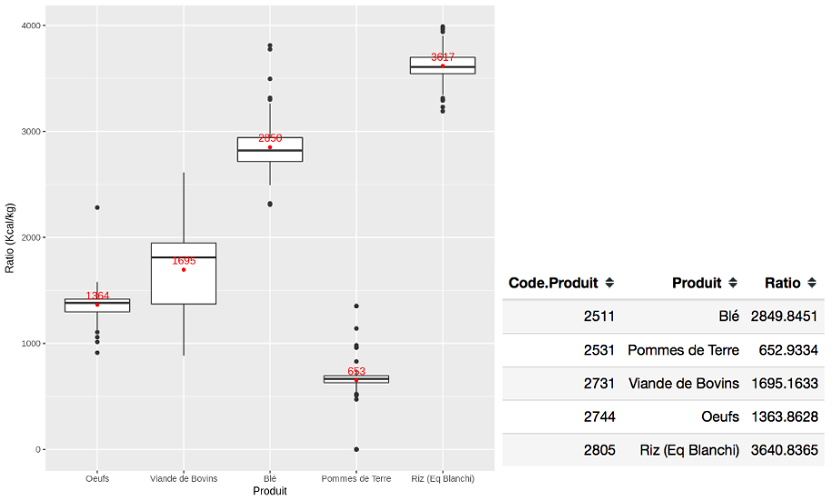

Une table de nutrition de référence dénommée [Table Ciqual](https://ciqual.anses.fr/) permet de revalider les résultats obtenus.

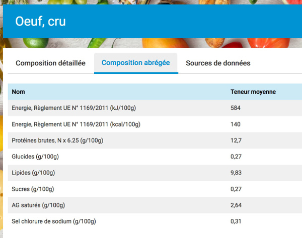

### Méthode ne nécessitant pas de connaitre la population

```r
RatioKcalKg2k13 <- (FBS
 %>% filter(Code.Élément%in%c(664,645)&Année==AnnéeÉtudiée) # dispo en KCal/personne/jour
 %>% dcast(Code.Pays+Pays+Code.Produit+Produit+Année~Code.Élément,value.var="Valeur")
 %>% rename("DispoKcal"="664","DispoKg"="645")
 %>% group_by(Code.Produit,Produit)
 %>% summarise(Ratio=mean(DispoKcal*365/DispoKg,na.rm=T))
 %>% filter(is.finite(Ratio)))
RatioKcalKg2k13 %>% filter(Produit%in%liste_produits)
```

| Code.Produit | Produit | Ratio |
| --- | --- | --- |
| 2511 | Blé | 2849.8451 |
| 2531 | Pommes de Terre | 652.9334 |
| 2731 | Viande de Bovins | 1695.1633 |
| 2744 | Oeufs | 1363.8628 |
| 2805 | Riz (Eq Blanchi) | 3640.8365 |

```r
# Graphe estimation du modèle (moyenne)
# library(ggplot2)
# fun_mean <- function(x){ return(round(data.frame(y=mean(x),label=mean(x,na.rm=T))))}
# sample <- Dispo2k13 %>% filter(Produit %in% liste_produits & Ratio<4000)
# ggplot(data=sample, aes(y=Ratio,x=Produit)) + geom_boxplot() + labs(x="Produit", y="Ratio (Kcal/kg)") +
#   stat_summary(fun.y=mean, geom="point", shape=20, size=2, color="red", fill="red") +
#   stat_summary(fun.data = fun_mean, geom="text", color="red", vjust=-0.7)
```

## Production mondiale exprimée en kcal

A partir de l'information sur la disponibilité alimentaire en kcal (par pays et par produit) que vous avez déterminée, calculez, pour les produits végétaux uniquement, la production mondiale exprimée en kcal.

```r
# utilisation comme masque
Dispo2k13Végétaux <- Dispo2k13 %>% right_join(ListeProduitsVégétaux,by=c("Code.Produit"))

# Calcul somme de la disponibilité alimentaire mondiale en Kcal
ProductionMondialeVégétaux2k13 <- (Dispo2k13Végétaux
        %>% summarise(ProductionMondialeVégétaux2k13=sum(DispoKcal,na.rm=T)))
ProductionMondialeVégétaux2k13
```

| ProductionMondialeVégétaux2k13 |
| --- |
| 6.090345e+15 |

Soit environ 6 millions de milliards de Kcal pour 2013

## Recommandation FAO

Renseignez-vous sur la recommandation (de la FAO si possible) concernant le nombre de calories par jour nécessaire à un être humain (Allez zou, on recherche sur internet ! ^^).

**Besoins énergétiques quotidiens approximatifs des adultes**

Normes fondées sur les rapports du Comité spécial mixte FAO/OMS/UNU d'experts sur les besoins en énergie et en protéines, 1985. Source : [FAO: La sous-alimentation dans le monde](http://www.fao.org/docrep/x8200f/X8200F03.htm)

|  | Activité légère (kcal) | Activité modérée (kcal) | Activité intense (kcal) |
| --- | --- | --- | --- |
| Hommes (stature 1,71 m)* |  |  |  |
| Masse corporelle minimum (54 kg) | 2 335 | 2 682 | 3 164 |
| Masse corporelle maximum (73 kg) | 2 786 | 3 199 | 3 775 |
| Femmes (stature 1,59 m)* |  |  |  |
| Masse corporelle minimum (47 kg) | 1 846 | 1 941 | 2 154 |
| Masse corporelle maximum (63 kg) | 2 223 | 2 337 | 2 594 |

**NécessitéKcalJourPersonne = 2586 Kcal (Valeur Moyenne)**

## Question : en terme de production de produits végétaux, combien d'humains pourraient être nourris si toute la production végétale était utilisée pour de la nourriture ?

```r
ProductionMondialeVégétaux2k13 <- (FBS_vegetal
 %>% filter(Code.Élément==5511&Année==AnnéeÉtudiée) # Production
 %>% select(Code.Pays,Code.Produit,Année,N=Valeur)
 %>% replace(is.na(.),0) # NA to 0
 %>% left_join(Population,by=c("Code.Pays","Année"))
 %>% left_join(RatioKcalKg2k13,by="Code.Produit")
 %>% mutate(DispoKg.bis=N*1e6) # en Kg/an
 %>% mutate(DispoKcal.bis=DispoKg.bis*Ratio) # en Kcal/an
 %>% select(c(-N,-Ratio))
 %>% summarise(Total2k13=sum(DispoKcal.bis,na.rm=T)))
cbind(Population %>% filter(Année==AnnéeÉtudiée) %>% summarise(Population=sum(Population)),
    round(ProductionMondialeVégétaux2k13 / 365 / NécessitéKcalJourPersonne))
```

| Population | Total2k13 |
| --- | --- |
| 7213211822 | 13481196669 |

😃 😃 😃

## Question : en terme de production de produits végétaux, combien d'humains pourraient être nourris si la production végétale, mis à part ses utilisations en Semence, Traitement et Autres utilisation, était utilisée pour de la nourriture ?

```r
(FBS_vegetal
 %>% filter(Code.Élément%in%c(5511,5527,5131,5154)&Année==AnnéeÉtudiée)
 %>% dcast(Code.Pays+Code.Produit~Code.Élément,value.var="Valeur")
 %>% rename("N"="5511","S"="5527","T"="5131","A"="5154")
 %>% replace(is.na(.),0) # NA to 0
 %>% left_join(RatioKcalKg2k13,by="Code.Produit")
 %>% mutate(DispoKg.bis=(N-S-T-A)*1e6) # en Kg/an
 %>% mutate(DispoKcal.bis=DispoKg.bis*Ratio) # en Kcal/an
 %>% select(c(-N,-S,-T,-A,-Ratio))
 %>% summarise(Total2k13=sum(DispoKcal.bis,na.rm=T)/365/NécessitéKcalJourPersonne))
```

| Total2k13 |
| --- |
| 10036223439 |

# Sous-alimentation

### Extrait du glossaire FAO Sécurité Alimentaire

```r
#glossaire_secu
read.csv("Glossaire_secu.csv",sep=";",header=T) %>% filter(grepl("sous-alim", Produit))
```

| Code.Produit | Produit | Description |
| --- | --- | --- |
| 21001 | Nombre de personnes sous-alimentées (millions) (moyenne sur 3 ans) | Estimated number of people at risk of undernourishment. It is calculated by applying the estimated prevalence of undernourishment to total population in each period. |
| 21004 | Prévalence de la sous-alimentation (%) (moyenne sur 3 ans) | The prevalence of undernourishment expresses the probability that a randomly selected individual from the population consumes an amount of calories that is insufficient to cover her/his energy require… |
| 99035 | Nombre de personnes sous-alimentées | Nombre de personnes en état de sous-alimentation. Pour obtenir le nombre de personnes sous-alimentées, on multiplie les estimations de la prévalence de la sous-alimentation par celles du total de la p… |
| 99036 | Prévalence de la sous-alimentation | Proportion de la population en état de sous-alimentation. "Sous-alimentation" fait référence à la situation des personnes dont l'apport énergétique alimentaire est en permanence inférieur au besoin én… |

A partir des données téléchargées qui concernent la sous-nutrition, répondez à cette question : Quelle proportion de la population mondiale est considérée comme étant en sous-nutrition ? (Donnez ce résultat pour l'année 2013 ainsi que pour la dernière année disponible).

```r
(SousAlim %>% filter(Année %in% c(2013,2015))
  %>% group_by(Année)
  %>% summarise(Sous.Alimentés=sum(Valeur,na.rm=T)*1e6) # en habitants
  %>% left_join(Population %>% group_by(Année) %>% summarise(Population=sum(Population)),by="Année")
  %>% mutate("% Total"=round(Sous.Alimentés*1e2/Population,2)))
```

| Année | Sous.Alimentés | Population | % Total |
| --- | --- | --- | --- |
| 2013 | 722900000 | 7213211822 | 10.02 |
| 2015 | 728600000 | 7382783059 | 9.87 |

# Céréales

Établissez la liste des produits (ainsi que leur code) considéré comme des céréales selon la FAO.

```r
FBS_cereales %>% group_by(Code.Produit) %>% summarise(Produit=first(Produit))
```

| Code.Produit | Produit |
| --- | --- |
| 2511 | Blé |
| 2513 | Orge |
| 2514 | Maïs |
| 2515 | Seigle |
| 2516 | Avoine |
| 2517 | Millet |
| 2518 | Sorgho |
| 2520 | Céréales, Autres |
| 2805 | Riz (Eq Blanchi) |

Sélectionnez (filtrez) dans vos données les informations concernant les céréales qui partent pour l'alimentation animale (en anglais : Feed).

```r
AlimentationAnimale2k13 <- (FBS_cereales
 %>% filter(Année==AnnéeÉtudiée&Code.Élément==5521) # Aliments pour animaux en Milliers de tonnes/an
 %>% select(Code.Pays,Pays,Code.Produit,Produit,Valeur)
 %>% mutate(Production=Valeur*1e6) %>% select(c(-Valeur))) # en kg
AlimentationAnimale2k13 %>% filter(Pays %in% liste_pays)
```

| Code.Pays | Pays | Code.Produit | Produit | Production |
| --- | --- | --- | --- | --- |
| 231 | États-Unis d'Amérique | 2511 | Blé | 6.19600e+09 |
| 231 | États-Unis d'Amérique | 2513 | Orge | 1.44000e+09 |
| 231 | États-Unis d'Amérique | 2514 | Maïs | 1.28024e+11 |
| 231 | États-Unis d'Amérique | 2515 | Seigle | 1.84000e+08 |
| 231 | États-Unis d'Amérique | 2516 | Avoine | 1.43000e+09 |
| 231 | États-Unis d'Amérique | 2517 | Millet | 3.94000e+08 |
| 231 | États-Unis d'Amérique | 2518 | Sorgho | 2.35100e+09 |
| 231 | États-Unis d'Amérique | 2520 | Céréales, Autres | 7.70000e+07 |
| 68 | France | 2511 | Blé | 7.82200e+09 |
| 68 | France | 2805 | Riz (Eq Blanchi) | 1.01000e+08 |
| 68 | France | 2513 | Orge | 2.86500e+09 |
| 68 | France | 2514 | Maïs | 5.20000e+09 |
| 68 | France | 2515 | Seigle | 9.00000e+07 |
| 68 | France | 2516 | Avoine | 3.76000e+08 |
| 68 | France | 2517 | Millet | 2.00000e+07 |
| 68 | France | 2518 | Sorgho | 2.08000e+08 |
| 68 | France | 2520 | Céréales, Autres | 2.42100e+09 |
| 100 | Inde | 2511 | Blé | 1.87000e+09 |
| 100 | Inde | 2805 | Riz (Eq Blanchi) | 2.12400e+09 |
| 100 | Inde | 2513 | Orge | 1.58000e+08 |
| 100 | Inde | 2514 | Maïs | 6.99000e+09 |
| 100 | Inde | 2516 | Avoine | 6.00000e+06 |
| 100 | Inde | 2517 | Millet | 2.18000e+08 |
| 100 | Inde | 2518 | Sorgho | 5.30000e+07 |
| 170 | Pérou | 2513 | Orge | 5.60000e+07 |
| 170 | Pérou | 2514 | Maïs | 2.86400e+09 |
| 170 | Pérou | 2516 | Avoine | 4.50000e+07 |
| 170 | Pérou | 2517 | Millet | 0.00000e+00 |
| 170 | Pérou | 2518 | Sorgho | 1.90000e+07 |
| 170 | Pérou | 2520 | Céréales, Autres | 3.00000e+06 |
| 351 | Chine | 2511 | Blé | 2.66940e+10 |
| 351 | Chine | 2805 | Riz (Eq Blanchi) | 1.21170e+10 |
| 351 | Chine | 2513 | Orge | 3.00000e+07 |
| 351 | Chine | 2514 | Maïs | 1.53802e+11 |
| 351 | Chine | 2515 | Seigle | 4.80000e+08 |
| 351 | Chine | 2516 | Avoine | 5.00000e+08 |
| 351 | Chine | 2517 | Millet | 8.00000e+08 |
| 351 | Chine | 2518 | Sorgho | 1.99800e+09 |
| 351 | Chine | 2520 | Céréales, Autres | 6.61000e+08 |

A l'aide de la table donnant les ratios énergie/poids de chaque aliment (que vous avez établie précédemment), convertir ces données (filtrées) en kcal.

```r
(AlimentationAnimale2k13
 %>% right_join(RatioKcalKg2k13%>%select(Code.Produit,Ratio),by="Code.Produit") # en KCal/kg
 %>% mutate(Valeur.énèrgétique=Production*Ratio) # en KCal
 %>% select(c(-Production,-Ratio))
 %>% filter(Pays %in% liste_pays))
```

| Code.Pays | Pays | Code.Produit | Produit | Valeur.énèrgétique |
| --- | --- | --- | --- | --- |
| 231 | États-Unis d'Amérique | 2511 | Blé | 1.765764e+13 |
| 68 | France | 2511 | Blé | 2.229149e+13 |
| 100 | Inde | 2511 | Blé | 5.329210e+12 |
| 351 | Chine | 2511 | Blé | 7.607377e+13 |
| 231 | États-Unis d'Amérique | 2513 | Orge | 2.852143e+12 |
| 68 | France | 2513 | Orge | 5.674576e+12 |
| 100 | Inde | 2513 | Orge | 3.129435e+11 |
| 170 | Pérou | 2513 | Orge | 1.109167e+11 |
| 351 | Chine | 2513 | Orge | 5.941965e+10 |
| 231 | États-Unis d'Amérique | 2514 | Maïs | 3.751997e+14 |
| 68 | France | 2514 | Maïs | 1.523963e+13 |
| 100 | Inde | 2514 | Maïs | 2.048558e+13 |
| 170 | Pérou | 2514 | Maïs | 8.393520e+12 |
| 351 | Chine | 2514 | Maïs | 4.507473e+14 |
| 231 | États-Unis d'Amérique | 2515 | Seigle | 3.754603e+11 |
| 68 | France | 2515 | Seigle | 1.836491e+11 |
| 351 | Chine | 2515 | Seigle | 9.794616e+11 |
| 231 | États-Unis d'Amérique | 2516 | Avoine | 2.537398e+12 |
| 68 | France | 2516 | Avoine | 6.671761e+11 |
| 100 | Inde | 2516 | Avoine | 1.064643e+10 |
| 170 | Pérou | 2516 | Avoine | 7.984820e+10 |
| 351 | Chine | 2516 | Avoine | 8.872023e+11 |
| 231 | États-Unis d'Amérique | 2517 | Millet | 1.172834e+12 |
| 68 | France | 2517 | Millet | 5.953471e+10 |
| 100 | Inde | 2517 | Millet | 6.489283e+11 |
| 170 | Pérou | 2517 | Millet | 0.000000e+00 |
| 351 | Chine | 2517 | Millet | 2.381388e+12 |
| 231 | États-Unis d'Amérique | 2518 | Sorgho | 7.001508e+12 |
| 68 | France | 2518 | Sorgho | 6.194443e+11 |
| 100 | Inde | 2518 | Sorgho | 1.578392e+11 |
| 170 | Pérou | 2518 | Sorgho | 5.658386e+10 |
| 351 | Chine | 2518 | Sorgho | 5.950239e+12 |
| 231 | États-Unis d'Amérique | 2520 | Céréales, Autres | 1.850790e+11 |
| 68 | France | 2520 | Céréales, Autres | 5.819171e+12 |
| 170 | Pérou | 2520 | Céréales, Autres | 7.210869e+09 |
| 351 | Chine | 2520 | Céréales, Autres | 1.588795e+12 |
| 68 | France | 2805 | Riz (Eq Blanchi) | 3.677245e+11 |
| 100 | Inde | 2805 | Riz (Eq Blanchi) | 7.733137e+12 |
| 351 | Chine | 2805 | Riz (Eq Blanchi) | 4.411602e+13 |

De la même manière que vous avez calculé la table des ratios énergie/poids , calculez les ratios poids de protéines/poids total

```r
RatioProtKg2k13 <- (FBS
 %>% filter(Code.Élément%in%c(645,674))
 %>% dcast(Code.Pays+Pays+Année+Produit+Code.Produit~Code.Élément,value.var="Valeur")
 %>% rename("DispoKg"="645","DispoProt"="674")
 %>% group_by(Code.Produit,Produit)
 %>% summarise(Ratio=sum(DispoProt*365)/sum(DispoKg)) # protéines en g/kg
 %>% na.omit())
RatioProtKg2k13 %>% filter(Produit%in%liste_produits)
```

| Code.Produit | Produit | Ratio |
| --- | --- | --- |
| 2511 | Blé | 83.12088 |
| 2531 | Pommes de Terre | 15.29656 |
| 2731 | Viande de Bovins | 143.54597 |
| 2744 | Oeufs | 107.92328 |
| 2805 | Riz (Eq Blanchi) | 69.85045 |

puis convertissez ces données (filtrées) en terme de protéines (unité : gramme).

```r
(AlimentationAnimale2k13
 %>% right_join(RatioProtKg2k13,by=c("Code.Produit")) # en g/kg
 %>% na.omit() # nettoyage
 %>% mutate(Protéines.brutes=Production*Ratio) # en g
 %>% select(c(-Production,-Ratio))
 %>% filter(Pays %in% liste_pays))
```

| Code.Pays | Pays | Code.Produit | Produit.x | Produit.y | Protéines.brutes |
| --- | --- | --- | --- | --- | --- |
| 231 | États-Unis d'Amérique | 2511 | Blé | Blé | 5.150170e+11 |
| 68 | France | 2511 | Blé | Blé | 6.501715e+11 |
| 100 | Inde | 2511 | Blé | Blé | 1.554360e+11 |
| 351 | Chine | 2511 | Blé | Blé | 2.218829e+12 |
| 231 | États-Unis d'Amérique | 2518 | Sorgho | Sorgho | 2.052192e+11 |
| 68 | France | 2518 | Sorgho | Sorgho | 1.815635e+10 |
| 100 | Inde | 2518 | Sorgho | Sorgho | 4.626379e+09 |
| 170 | Pérou | 2518 | Sorgho | Sorgho | 1.658513e+09 |
| 351 | Chine | 2518 | Sorgho | Sorgho | 1.744057e+11 |
| 68 | France | 2805 | Riz (Eq Blanchi) | Riz (Eq Blanchi) | 7.054895e+09 |
| 100 | Inde | 2805 | Riz (Eq Blanchi) | Riz (Eq Blanchi) | 1.483623e+11 |
| 351 | Chine | 2805 | Riz (Eq Blanchi) | Riz (Eq Blanchi) | 8.463779e+11 |

## Question : quelle proportion (en terme de poids) de la disponibilité mondiale de céréales est destinée à l'alimentation animale ?

```r
(cbind((FBS_cereales
 %>% filter(Code.Élément==5301&Année==AnnéeÉtudiée) # Disponibilité intérieure en milliers de tonnes/an
 %>% summarise(D=sum(Valeur))),
(FBS_cereales
 %>% filter(Code.Élément==5521&Année==AnnéeÉtudiée) # Aliments pour animaux en milliers de tonnes /an
 %>% summarise(A=sum(Valeur))))
 %>% mutate(T=round(A*100/D,2))
 %>% rename("Disponibilité intérieure"=D,"Aliments pour animaux"=A,"% Total"=T))
```

| Disponibilité intérieure | Aliments pour animaux | % Total |
| --- | --- | --- |
| 2898317 | 1070617 | 36.94 |

Avec l'aide des tables énergie/poids et poids de protéines/poids total, calculez la disponibilité mondiale totale de produit **animaux**, que vous exprimerez en kcal et en grammes de protéines.

Depuis "Disponibilité alimentaire en quantité"

```r
cbind((FBS_animal
 %>% filter(Code.Élément==645&Année==AnnéeÉtudiée) # Disponibilité alimentaire en quantité (kg/personne/an)
 %>% right_join((RatioKcalKg2k13%>%select(Code.Produit,Ratio)),by="Code.Produit") # en Kcal/kg
 %>% mutate(R=Valeur*Ratio) # en Kcal/personne/an
 %>% summarise(Énergie=sum(R,na.rm=T))*Population2k13*.514) , # en Kcal/an
(FBS_animal
 %>% filter(Code.Élément==645&Année==AnnéeÉtudiée) # Disponibilité alimentaire en quantité (kg/personne/an)
 %>% right_join((RatioProtKg2k13%>%select(Code.Produit,Ratio)),by="Code.Produit") # en g/kg
 %>% mutate(R=Valeur*Ratio) # en g/personne/an
 %>% summarise(Poids.Protéines=sum(R,na.rm=T))*Population2k13*.514)) # en g/an
```

| Énergie | Poids.Protéines |
| --- | --- |
| 1.279455e+17 | 7.546513e+15 |

Depuis "Disponibilité intérieure en milliers de tonnes"

```r
cbind((FBS_animal
 %>% filter(Code.Élément==5301&Année==AnnéeÉtudiée) # Disponibilité intérieure en milliers de tonnes
 %>% right_join((RatioKcalKg2k13%>%select(Code.Produit,Ratio)),by="Code.Produit") # en Kcal/kg
 %>% summarise(Énergie=sum(Valeur*1e6*Ratio,na.rm=T))), # en Kcal/an
(FBS_animal
 %>% filter(Code.Élément==5301&Année==AnnéeÉtudiée) # Disponibilité intérieure en milliers de tonnes
 %>% right_join((RatioProtKg2k13%>%select(Code.Produit,Ratio)),by="Code.Produit") # en g/kg
 %>% summarise(Poids.Protéines=sum(Valeur*1e6*Ratio,na.rm=T)))) # en g/an
```

| Énergie | Poids.Protéines |
| --- | --- |
| 1.460703e+15 | 7.845589e+13 |

Calculez les 3 valeurs du ratio suivant, lorsque les quantités sont exprimées en kg, puis en kcal, puis en grammes de protéines : *Disponibilité de céréales destinée à l'alimentation animale / Disponibilité animale destinée à l'alimentation humaine*

```r
cbind(((AlimentationAnimale2k13
 %>% summarise(RatioKg=sum(Production))) # Disponibilité de céréales destinée à l'alimentation animale en kg
 / (FBS_animal
 %>% filter(Code.Élément==645&Année==AnnéeÉtudiée)
 %>% summarise(sum(Valeur))*Population2k13)) # Disponibilité poids source animale en kg
,
((AlimentationAnimale2k13
 %>% right_join(RatioKcalKg2k13,by="Code.Produit")
 %>% summarise(RatioKcal=sum(Production*Ratio,na.rm=T)))
 / (FBS_animal
 %>% filter(Code.Élément==664&Année==AnnéeÉtudiée)
 %>% summarise(sum(Valeur))*Population2k13*365)) # Disponibilité énergie source animale en Kcal/an
,
((AlimentationAnimale2k13
 %>% right_join(RatioProtKg2k13,by="Code.Produit")
 %>% summarise(RatioProt=sum(Production*Ratio,na.rm=T)))
 / (FBS_animal
 %>% filter(Code.Élément==674&Année==AnnéeÉtudiée)
 %>% summarise(sum(Valeur))*Population2k13*365))) # Disponibilité protéines source animale en g/an
```

| RatioKg | RatioKcal | RatioProt |
| --- | --- | --- |
| 0.004403513 | 0.0122864 | 0.00112698 |

## Question : Combien de kg de céréales sont nécessaires pour produire 1kg de viande ?

```r
0.004403513^-1
```

227.091415422187

# Entrez vos données dans une base de données relationnelle

```r
require("RPostgreSQL"); pw <- {"abc1234"}; drv <- dbDriver("PostgreSQL")
con <- dbConnect(drv,dbname="postgres",host="postgres",port=5432,user="postgres",password=pw)
rm(pw)
```

Une table appelée population, contenant la population de chaque pays pour chaque année comprise entre 2010 et la dernière année disponible à la date où vous aurez consulté le site de la FAO.

Elle devra contenir 4 colonnes : pays, code_pays, annee, population.

A faire : Proposez une clé primaire pertinente pour cette table.

```r
population <- as.data.frame(Population_2[Population_2$Code.Élément==511,]
 %>% group_by(pays=Zone,code_pays=Code.zone,annee=Année)
 %>% summarise(population=sum(Valeur)*1000))
row.names(population) <- sprintf('%d%d',population$code_pays,population$annee)

dbWriteTable(con,"population",population,overwrite=T,row.names=T)
dbGetQuery(con, "SELECT COUNT(*) from population")
dbGetQuery(con, "SELECT * from population LIMIT 5")
```

TRUE

| count |
| --- |
| 1812 |

| row.names | pays | code_pays | annee | population |
| --- | --- | --- | --- | --- |
| 22010 | Afghanistan | 2 | 2010 | 28803200 |
| 22011 | Afghanistan | 2 | 2011 | 29708600 |
| 22012 | Afghanistan | 2 | 2012 | 30697000 |
| 22013 | Afghanistan | 2 | 2013 | 31731700 |
| 22014 | Afghanistan | 2 | 2014 | 32758000 |

Une table appelée dispo_alim contenant pour chaque pays, pour chaque produit, et pour chaque année comprise entre 2010 et la dernière année disponible, les informations suivantes:

la nature du produit (deux valeurs possibles : “animal” ou “végétal”)

disponibilité alimentaire en tonnes

disponibilité alimentaire en Kcal/personne/jour

disponibilité de protéines en g/personne/jour

disponibilité de matières grasses en g/personne/jour

Elle devra contenir ces colonnes : pays, code_pays, année, produit, code_produit, dispo_alim_tonnes, dispo_alim_kcal_p_j, dispo_prot, dispo_mat_gr .

A faire : Proposez une clé primaire pertinente pour cette table.

```r
dispo_alim <- as.data.frame(FBS
  %>% filter(Code.Élément%in%c(645,664,674,684))
  %>% dcast(Code.Pays+Pays+Année+Produit+Code.Produit~Code.Élément,value.var="Valeur")
  %>% rename("dispo_alim_tonnes"="645","dispo_alim_kcal_p_j"="664","dispo_prot"="674","dispo_mat_gr"="684")
  %>% rename(pays=Pays,code_pays=Code.Pays,année=Année,produit=Produit,code_produit=Code.Produit)
  %>% mutate(nature=ifelse(code_produit%in%ListeProduitsVégétaux$Code.Produit,"végétal","animal"))
  %>% mutate(dispo_alim_tonnes=dispo_alim_tonnes/1e3)
  %>% replace(is.na(.), 0)) # NA to 0
rownames(dispo_alim) <- sprintf('%d%d%d',dispo_alim$code_pays,dispo_alim$code_produit,dispo_alim$année)

dbWriteTable(con,"dispo_alim",dispo_alim,overwrite=T,row.names=T)
dbGetQuery(con, "SELECT COUNT(*) FROM dispo_alim")
dbGetQuery(con, "SELECT * FROM dispo_alim LIMIT 5")
```

TRUE

| count |
| --- |
| 56083 |

| row.names | code_pays | pays | année | produit | code_produit | dispo_alim_tonnes | dispo_alim_kcal_p_j | dispo_prot | dispo_mat_gr | nature |
| --- | --- | --- | --- | --- | --- | --- | --- | --- | --- | --- |
| 127362010 | 1 | Arménie | 2010 | Abats Comestible | 2736 | 0.00444 | 13 | 2.18 | 0.37 | animal |
| 127692010 | 1 | Arménie | 2010 | Animaux Aquatiques Autre | 2769 | 0.00000 | 0 | 0.00 | 0.00 | animal |
| 127402010 | 1 | Arménie | 2010 | Beurre, Ghee | 2740 | 0.00137 | 27 | 0.03 | 3.05 | animal |
| 127662010 | 1 | Arménie | 2010 | Cephalopodes | 2766 | 0.00001 | 0 | 0.00 | 0.00 | animal |
| 127432010 | 1 | Arménie | 2010 | Crème | 2743 | 0.00001 | 0 | 0.00 | 0.00 | animal |

Une table appelée equilibre_prod contenant pour chaque pays, pour chaque produit, et pour chaque année comprise entre 2010 et la dernière année disponible, les quantités suivantes :

disponibilité intérieure

aliments pour animaux

semences

pertes

transformés traitement

nourriture

autres utilisations

Elle devra contenir ces colonnes : pays, code_pays, année, produit, code_produit, dispo_int, alim_ani, semences, pertes, transfo, nourriture, autres_utilisations.

A faire : Proposez une clé primaire pertinente pour cette table.

```r
equilibre_prod <- as.data.frame(FBS
  %>% filter(Code.Élément%in%c(5301,5521,5527,5123,5131,5142,5154))
  %>% dcast(Code.Pays+Pays+Année+Produit+Code.Produit~Code.Élément,value.var="Valeur")
  %>% rename("dispo_int"="5301","alim_ani"="5521","semences"="5527","pertes"="5123",
             "transfo"="5131","nourriture"="5142","autres_utilisations"="5154")
  %>% rename(pays=Pays,code_pays=Code.Pays,année=Année,produit=Produit,code_produit=Code.Produit)
  %>% replace(is.na(.), 0)) # NA to 0
rownames(equilibre_prod) <- sprintf('%d%d%d',equilibre_prod$code_pays,equilibre_prod$code_produit,equilibre_prod$année)

dbWriteTable(con,"equilibre_prod",equilibre_prod,overwrite=T,row.names=T)
dbGetQuery(con, "SELECT COUNT(*) from equilibre_prod")
dbGetQuery(con, "SELECT * FROM equilibre_prod LIMIT 5")
```

TRUE

| count |
| --- |
| 60508 |

| row.names | code_pays | pays | année | produit | code_produit | pertes | transfo | nourriture | autres_utilisations | dispo_int | alim_ani | semences |
| --- | --- | --- | --- | --- | --- | --- | --- | --- | --- | --- | --- | --- |
| 127362010 | 1 | Arménie | 2010 | Abats Comestible | 2736 | 0 | 0 | 13 | 1 | 14 | 0 | 0 |
| 127692010 | 1 | Arménie | 2010 | Animaux Aquatiques Autre | 2769 | 0 | 0 | 0 | 0 | 0 | 0 | 0 |
| 127402010 | 1 | Arménie | 2010 | Beurre, Ghee | 2740 | 0 | 0 | 4 | 0 | 4 | 0 | 0 |
| 127662010 | 1 | Arménie | 2010 | Cephalopodes | 2766 | 0 | 0 | 0 | 0 | 0 | 0 | 0 |
| 127432010 | 1 | Arménie | 2010 | Crème | 2743 | 0 | 0 | 0 | 0 | 0 | 0 | 0 |

Une table appelée sous_nutrition, contenant le nombre de personnes en sous-alimentation pour chaque pays et pour chaque année comprise entre 2010 et la dernière année disponible.

Elle devra contenir 4 colonnes : pays, code_pays, année, nb_personnes.

A faire : Proposez une clé primaire pertinente pour cette table.

```r
sous_nutrition <- as.data.frame(SousAlim
 %>% mutate(année=as.integer(sub("(\\d{4})-.+","\\1", Année))+1)
 %>% group_by(pays=Zone,code_pays=Code.zone,année)
 %>% summarise(nb_personnes=round(sum(Valeur/3,na.rm=T),6)*1e6) # en habitants
 %>% filter(nb_personnes>0))
rownames(sous_nutrition) <- sprintf('%d%d',sous_nutrition$code_pays,sous_nutrition$année)

dbWriteTable(con,"sous_nutrition",sous_nutrition,overwrite=T,row.names=T)
dbGetQuery(con, "SELECT COUNT(*) from sous_nutrition")
dbGetQuery(con, "SELECT * FROM sous_nutrition LIMIT 5")
```

TRUE

| count |
| --- |
| 486 |

| row.names | pays | code_pays | année | nb_personnes |
| --- | --- | --- | --- | --- |
| 22012 | Afghanistan | 2 | 2012 | 2133333 |
| 22013 | Afghanistan | 2 | 2013 | 2266667 |
| 22014 | Afghanistan | 2 | 2014 | 2400000 |
| 22015 | Afghanistan | 2 | 2015 | 2500000 |
| 22016 | Afghanistan | 2 | 2016 | 2500000 |

### A faire : Écrivez les requêtes SQL permettant de connaître…

Les 10 pays ayant le plus haut ratio disponibilité alimentaire/habitant en terme de protéines (en kg) par habitant, puis en terme de kcal par habitant.

```r
# ratio disponibilité alimentaire en protéines (en kg) par habitant
dbGetQuery(con, "SELECT pays,SUM(dispo_prot)/1000 AS dispo_prot_kg, SUM(dispo_alim_kcal_p_j) AS dispo_kcal
                    FROM dispo_alim  WHERE année=2013 GROUP BY pays
                    ORDER BY(dispo_prot_kg) DESC LIMIT 10")
```

| pays | dispo_prot_kg | dispo_kcal |
| --- | --- | --- |
| Islande | 0.13306 | 3381 |
| Israël | 0.12800 | 3610 |
| Lituanie | 0.12436 | 3414 |
| Maldives | 0.12232 | 2733 |
| Finlande | 0.11756 | 3366 |
| Luxembourg | 0.11364 | 3540 |
| Monténégro | 0.11190 | 3490 |
| Pays-Bas | 0.11146 | 3222 |
| Albanie | 0.11137 | 3188 |
| Portugal | 0.11087 | 3472 |

```r
# ratio disponibilité alimentaire en kcal par habitant
dbGetQuery(con, "SELECT  pays, SUM(dispo_alim_kcal_p_j) AS dispo_kcal,
                    SUM(dispo_prot)/1000 AS dispo_prot_kg
                    FROM dispo_alim  WHERE année=2013 GROUP BY pays
                    ORDER BY(dispo_kcal) DESC LIMIT 10")
```

| pays | dispo_kcal | dispo_prot_kg |
| --- | --- | --- |
| Autriche | 3770 | 0.10620 |
| Belgique | 3737 | 0.09937 |
| Turquie | 3708 | 0.10812 |
| États-Unis d'Amérique | 3682 | 0.10942 |
| Israël | 3610 | 0.12800 |
| Irlande | 3602 | 0.10991 |
| Italie | 3578 | 0.10849 |
| Luxembourg | 3540 | 0.11364 |
| Égypte | 3518 | 0.10322 |
| Allemagne | 3503 | 0.10139 |

Les 10 pays ayant le plus faible ratio disponibilité alimentaire/habitant en terme de protéines (en kg) par habitant, puis en terme de kcal par habitant.

```r
# ratio disponibilité alimentaire en protéines (en kg) par habitant
dbGetQuery(con, "SELECT pays,SUM(dispo_prot)/1000 AS dispo_prot_kg, SUM(dispo_alim_kcal_p_j)
                    AS dispo_kcal FROM dispo_alim  WHERE année=2013 GROUP BY pays
                    ORDER BY(dispo_prot_kg) ASC LIMIT 10")
```

| pays | dispo_prot_kg | dispo_kcal |
| --- | --- | --- |
| Libéria | 0.03766 | 2206 |
| Guinée-Bissau | 0.04405 | 2288 |
| Mozambique | 0.04568 | 2282 |
| République centrafricaine | 0.04604 | 1879 |
| Madagascar | 0.04669 | 2056 |
| Haïti | 0.04770 | 2089 |
| Zimbabwe | 0.04832 | 2113 |
| Congo | 0.05141 | 2206 |
| Ouganda | 0.05264 | 2126 |
| Sao Tomé-et-Principe | 0.05310 | 2398 |

```r
# ratio disponibilité alimentaire en kcal par habitant
dbGetQuery(con, "SELECT pays,SUM(dispo_alim_kcal_p_j) AS dispo_kcal ,
                    SUM(dispo_prot)/1000 AS dispo_prot_kg
                    FROM dispo_alim  WHERE année=2013 GROUP BY pays
                    ORDER BY(dispo_kcal) ASC LIMIT 10")
```

| pays | dispo_kcal | dispo_prot_kg |
| --- | --- | --- |
| République centrafricaine | 1879 | 0.04604 |
| Zambie | 1924 | 0.05522 |
| Madagascar | 2056 | 0.04669 |
| Afghanistan | 2087 | 0.05826 |
| Haïti | 2089 | 0.04770 |
| République populaire démocratique de Corée | 2093 | 0.05499 |
| Tchad | 2109 | 0.06275 |
| Zimbabwe | 2113 | 0.04832 |
| Ouganda | 2126 | 0.05264 |
| Éthiopie | 2129 | 0.06039 |

```r
dbGetQuery(con, "SELECT pays,nb_personnes FROM sous_nutrition WHERE année=2013
                    GROUP BY pays,nb_personnes
                    ORDER BY(nb_personnes) DESC LIMIT 10;")
```

| pays | nb_personnes |
| --- | --- |
| Inde | 65033333 |
| Chine | 49866667 |
| Pakistan | 12400000 |
| Éthiopie | 9300000 |
| Bangladesh | 8700000 |
| Indonésie | 7100000 |
| République-Unie de Tanzanie | 5266667 |
| Philippines | 4566667 |
| Ouganda | 3866667 |
| Viet Nam | 3733333 |

Les 10 produits pour lesquels le ratio Autres utilisations/Disponibilité intérieure est le plus élevé.

```r
dbGetQuery(con, "SELECT * FROM (
                    SELECT pays,produit,autres_utilisations/nullif(dispo_int, 0) AS ratio
                    FROM equilibre_prod
                    WHERE année=2013
                    GROUP BY (pays,produit,ratio)
                    ) AS res
                    WHERE ratio IS NOT NULL
                    ORDER BY ratio DESC
                    LIMIT 10")
```

| pays | produit | ratio |
| --- | --- | --- |
| États-Unis d'Amérique | Huil Plantes Oleif Autr | 5.045455 |
| Uruguay | Graisses Animales Crue | 3.500000 |
| Norvège | Huile de Palme | 2.000000 |
| Canada | Plantes Oleiferes, Autre | 1.952381 |
| Canada | Huil Plantes Oleif Autr | 1.394737 |
| République de Moldova | Huile de Palme | 1.333333 |
| Maroc | Huile de Palme | 1.227273 |
| Kazakhstan | Huile de Palme | 1.222222 |
| Roumanie | Huil Plantes Oleif Autr | 1.222222 |
| Chili | Huil Plantes Oleif Autr | 1.133333 |

### Question : pour quelques uns des produits identifiés dans cette dernière requête SQL, supposez quelles sont ces "autres utilisations" possibles (recherchez sur internet !)

# Huile de palme

Source : [Wikipédia](https://fr.wikipedia.org/wiki/Huile_de_palme)

À l'échelle mondiale, l’huile de palme est principalement utilisée dans l’industrie alimentaire (80 %), dans **l’oléochimie** (savon, cosmétiques…) (19 %) et en tant qu’ **agrocarburant** (1 %).

### Oléochimie

L'huile de palme est également utilisée dans la synthèse de nombreux produits cosmétiques. C'est le cas par exemple de certains savons, où elle est utilisée pour la saponification. Le composé est alors appelé sodium palmate (et sodium palm kerenelate dans le cas de l'huile de palmiste). Elle est également utilisée pour la parfumerie sous la forme de civettone, et comme agent hydratant dans les crèmes. Elle est par ailleurs utilisée dans d'autres industries comme lubrifiant.

### Agro-carburants

Par rapport aux autres huiles, le rendement de l'huile de palme en fait un choix privilégié pour la production d'agrocarburant. Mais sa composition en fait un carburant que l'on ne peut insérer qu'en quantité limitée car elle fige dans les réservoirs.

[figure not shown]